# AI Skills in Action: From Messy Project to Reproducibility Package

A hands-on session with AI Skills + the WB Reproducibility Package skill

María Reyes Retana

Reproducible Research Initiative · DECDI

2026-09-14

## Objective

Produce a **well-structured reproducibility package that runs on someone else’s computer and meets all requirements**.

Two starting points:

- A package that **already exists**, but you’re not sure it meets the reproducibility standards.
- Code **written without reproducibility in mind**, a legacy or side project.

> The skill embeds the *exact checks the reproducibility team applies as reviewers.* Passing its audit means passing completeness check, and skipping the resubmissions where most calendar time is lost.

## Agenda

**Part 1 — Background**

0. Setup check — do you have everything?
1. What are AI skills?
2. What this skill does, phase by phase

**Part 2 — Practice**

3. Hands-on demo/exercise
4. Wrap-up

# Part 1 · Background

## Are we ready?

Before we begin make sure we have everything we need:

- These slides (useful to copy links): https://bit.ly/ai-reproducibility.
- **Visual Studio Code** installed (available in the Software Center for Windows, SelfService for Mac)
- One of the two, signed in within VS Code:
  - **GitHub Copilot** (Copilot Chat extension, with a Claude model available), or
  - The **Claude Code extension**, linked to a personal Claude account
- Demo project, available [here](https://github.com/dime-worldbank/ai-research-training/raw/refs/heads/main/sessions/ai-skills-reproducibility/materials/demo-project.zip)
- Our AI skill, available in [our repo](https://github.com/worldbank/wb-reproducible-research-repository/tree/main/ai-skills/reproducibility-skill); [direct download](https://github.com/worldbank/wb-reproducible-research-repository/releases/download/skill-v2026.07.08/reproducibility-skill.zip)

## What is an AI skill?

A **skill** is a folder of instructions, scripts, and resources that an AI agent reads to improve performance on specialized tasks. When you ask it to complete a task, the agent reviews the available skills, loads the relevant ones, and applies their instructions.

Our skill…

```
.agents/skills/reproducibility-skill/
├── SKILL.md              # A 4-phase workflow
├── references/
│   ├── checklist.md      # official WB package requirements
│   ├── flags.md          # 14 common failure flags with detection patterns
│   └── datasets.md       # WDI, PWT, OECD, ILO — licenses and citation formats
└── assets/
    ├── README_template.md # Our reproducibility README template
    ├── README_example.md  # Example of a great README
    └── main.do / main.R / main.py # Example of main files for projects
```

The agent loads it **only when triggered**, and reads the actual reference files, not its memory of them.

## Why a skill, and not just a prompt?

The reproducibility standard is too long to paste into a chat reliably: full checklist + **14 failure flags** based on the reproducibility team experience + assets and references.

| Without the skill | With the skill |
| --- | --- |
| You remember to check a few things | The agent checks **every item**, every time |
| Standard lives in someone’s head | Standard lives in files the agent reads |
| Each conversation starts from scratch | Guardrails are built into the workflow |
| Standard changes → tell everyone again | Update one file → everyone’s next run uses it |

## Skills architecture

Every skill has the same structure — ours included:

```
reproducibility-skill/
├── SKILL.md              ← always loaded once the skill triggers
├── references/           ← opened on demand, only when a phase needs them
│   ├── checklist.md          the official package requirements
│   ├── flags.md               F1–F14 detection patterns
│   └── datasets.md           WDI/PWT/OECD/ILO citation rules
└── assets/                ← used directly as deliverables, not "read"
    ├── README_template.md
    ├── README_example.md
    └── main.do / main.R / main.py
```

- **`SKILL.md`** — the dispatcher: short, always read, points to the rest
- **`references/`** — consulted mid-task (e.g. `flags.md` during the audit) — extends what the agent knows
- **`assets/`** — copied or filled in (e.g. `README_template.md` becomes the actual README) — extends what the agent produces

# Part 2 · The skill

## Four phases, with stop points

| Phase | What happens | Writes files? |
| --- | --- | --- |
| **1 · Audit** | Checks everything against checklist + flags F1–F14; classifies every data file | Read-only |
| **2 · Outline** | Proposes target structure, gap table — the build plan | Proposes only |
| **3 · Build** | Drafts README, DAS, main script; applies approved fixes | After your approval |
| **4 · Run check** | Sets outputs aside, reruns from scratch, verifies every exhibit regenerates | After your approval (you might need to run licensed code) |

## Phase 1 · Audit — two passes

The agent inventories the project and runs two passes in parallel:

**Checklist pass**

Every required component → **present / partial / missing**, with filename or line as evidence

*(Presence means verified against content, not just that a file exists)*

**Flag pass**

Flags F1–F14 → **PASS / FLAG / N/A**, with file and line number

Detection runs actual patterns — hardcoded paths, seeds, install commands, write operations

**+ Data ↔︎ README cross-check:** which files does the code *produce* vs. which are *external inputs*? Every external input needs a DAS entry.

## The 14 failure flags (F1–F14)

**Paths & structure**

- F1 · Hardcoded user-specific paths
- F2 · No single entry point
- F3 · Scattered `cd` / `setwd` in analysis scripts
- F12 · Outputs overwrite inputs

**Randomness & versions**

- F4 · Randomness without a seed
- F5 · User packages not installed by code
- F6 · Software versions not pinned

**Documentation**

- F7 · Manuscript–code version mismatch
- F8 · Input data missing from DAS
- F9 · Outputs not produced by code
- F10 · Missing README / List of Exhibits
- F11 · Extraneous files

**Special cases**

- F13 · Restricted data included by mistake
- F14 · Large-compute pathway not documented

## Phase 1 · Audit: what the agent checks

Goal: report the current state of the project against the standard. **Change nothing.**

- **Inventory** — every data file, script, output, README, manuscript
- **Checklist pass** — each item recorded as present / partial / missing, with file or line as evidence
- **Flag pass** — F1–F14 run via detection patterns (grep, not eyeballing): hardcoded paths, missing seeds, install commands…
- **README ↔︎ code** — every script, global, and version claim in the README verified against what the code actually does
- **Data ↔︎ DAS** — every external input classified, matched to a documented source; unknown provenance = blocking question
- **Exhibit coverage** — every table and figure maps to a script and an output that really gets written

**And then it stops.** Audit reports the facts, no fixes, no edits. Proposing changes is Phase 2.

## Phases 2–3 · Outline → Build

**Outline** *(nothing written to the project yet)*

- Maps every file into the standard three-folder tree: `data/ · code/ · output/`
- Entry-point rule: replicator changes a path in **exactly one place per language**, at the top of a main script
- Gap table: one row per checklist gap and per flag, with a concrete action to close each
- **Stops again**: you approve, edit, or reject rows before anything is built

**Build** *(only after approval)*

- README from the standard template: Overview, Data Availability Statement, Instructions, List of Exhibits, Requirements
- Main script(s): version statement, single path global, package installs, seeds, run order
- Re-runs the full Phase 1 audit as a final check

## Phase 4 · Run check

A package that audits clean but has never run from scratch **is not done**.

1. Build expected-output list from the List of Exhibits
2. Set existing outputs aside — **never deleted without your approval**
3. Rerun from a fresh start, changing only the designated path line
4. Verify every exhibit **regenerates**: fresh timestamp, non-empty, matches previous outputs
5. Record run times → into the README
6. Cleans the project and produces a final reproducibility package.
7. Reminds author to use this version of exhibits for the manuscript (version control)

Where the agent can’t execute (e.g., Stata): you get the **exact clean-run protocol** as a checklist, designed to catch paths pointing at the old project location.

# Part 3 · Hands-on

## Meet the demo project

Available [here](https://github.com/dime-worldbank/ai-research-training/raw/refs/heads/main/sessions/ai-skills-reproducibility/materials/demo-project.zip)

A cross-country study on **GDP per capita ↔︎ informality** in R, Stata, and Python.

```
demo-project/
├── analysis_final_v3.do    ← C:\Users\wb6878f9\Dropbox\...
├── bootstrap_se.do         ← C:\Users\wb6878f9\Dropbox\...
├── clean_wdi.R             ← C:\Users\wb6878f9\Dropbox\...
├── make_figure2.py         ← no seed; hardcoded path
├── data/
│   ├── wdi_gdppc_extract.csv
│   ├── pwt1001_extract.csv
│   ├── oecd_self_employment.csv
│   └── final_merged_v2.csv  ← ⚠ source unknown
├── output/
│   └── table1_FINAL_formatted_byhand.csv
├── notes/meeting_notes.txt  ← "where did v2 come from??"
└── old/analysis_v2_OLD.do
```

No README. No main script. No requirements file. No structure. No hope.

[figure not shown]

## Let’s set it up

We’ll set up the skill together — I’ll walk you through it.

1. **Download & unzip** the demo project, then open it in VS Code *File → Open Folder* — select the **folder**, not a file
2. **Add the skill:** create the folder structure and drop the skill in, from vs code terminal, or right-click new folder.

```bash
mkdir -p .agents/skills
```

Then copy the `reproducibility-skill/` folder into `.agents/skills/` so you have:

```
demo-project/
├── .agents/
│   └── skills/
│       └── reproducibility-skill/
│           └── SKILL.md
├── data/
├── code/
└── ...
```

3. **See skill** Check if skill is available by typing `/skill` — `reproducibility-skill` should be listed. If it does not appear you might need to close VS code and open again.

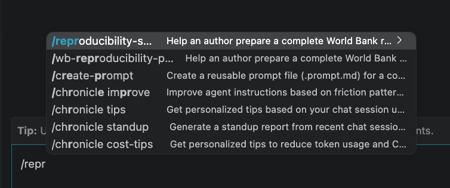

## Settings check

Set the extension to **Local**:

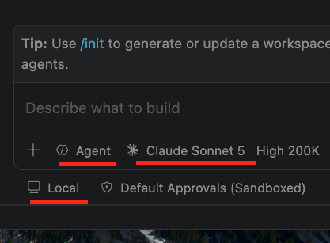

. . .

If you skip it and later see:

> `Claude CLI Error: Claude Code process exited with code 1`

**Fix:** start a new chat, then switch to **Local**.

## Let’s test it

3. **Open the Claude Code / Copilot chat panel** and type:

> *“Prepare a reproducibility package for this project.”*

The agent reads the skill, detects the match, and starts **Phase 1**.

We’ll use **git** to see what’s changing, good practice with AI agents.

If the skill is working the agent should tell you that is reading the reproducibility skill.

## For your own projects

Same setup, on your own, a one-time step per project:

1. **Download the skill** from the repo: [github.com/worldbank/wb-reproducible-research-repository](https://github.com/worldbank/wb-reproducible-research-repository/tree/main/ai-skills/reproducibility-skill) *(or the packaged `.zip` from the [releases page](https://github.com/worldbank/wb-reproducible-research-repository/releases/download/skill-v2026.07.08/reproducibility-skill.zip))*
2. **Create the folder structure** at your project root — from the VS Code terminal:

```bash
mkdir -p .agents/skills
```

3. **Copy `reproducibility-skill/`** into `.agents/skills/`:

```
your-project/
└── .agents/
    └── skills/
        └── reproducibility-skill/
            └── SKILL.md
```

Then open the chat panel and use the same prompt: > *“Prepare a reproducibility package for this project.”*

The agent picks up **any** skill placed in `.agents/skills/` automatically; exactly what we just did together.

## What you’ll see — the audit output

The agent produces tables before asking permission to continue:

```
Checklist status
──────────────────────────────────────
Component              Status
README                 MISSING
Data Availability Stmt MISSING
List of Exhibits       MISSING
Main script            MISSING

Flag results (10 FLAGS)
──────────────────────────────────────
F1  Hardcoded paths    FLAG  (4 files)
F2  No entry point     FLAG
F3  Scattered setwd    FLAG  clean_wdi.R:1
F4  No seed            FLAG  make_figure2.py
F5  Packages missing   FLAG
F6  Versions missing   FLAG
F8  Data not in DAS    FLAG  final_merged_v2.csv
F9  Output not code    FLAG  table1_..._byhand.csv
F10 No README          FLAG
F11 Extraneous files   FLAG  .DS_Store, notes/, old/
```

Then stops: *“Shall I proceed to the outline?”*

[figure not shown]

## What to watch for

We’ll stop and read at each gate before moving forward:

**During the audit**

- Does the agent catch all 10 flags?
- How does it handle `final_merged_v2.csv` — does it ask before guessing?
- What does it say about the meeting notes and `old/` folder?

**During outline and build**

- The gap table — one concrete action per flag
- The proposed folder restructure (code at root → `code/`)
- The main wrapper script for 3 languages
- Run-check protocol for Stata

→ Switching to VS Code now. Follow along or run it yourself — both are fine.

# Part 4 · Wrap-up

## When is a package “done”?

1. **Audit clean** — checklist complete, no open flags
2. **DAS complete** — every external input has confirmed source, URL, and access date
3. **One-click entry point** — one path to change per language, packages install, seeds set
4. **Exhibit mapping** — every table and figure maps to a script and an output file
5. **Clean rerun** — ran from scratch, every exhibit regenerated with a fresh timestamp

[figure not shown]

## Use it on your own project

**Get the skill:**

https://github.com/worldbank/wb-reproducible-research-repository/tree/main/ai-skills/reproducibility-skill

→ Copy `.agents/skills/reproducibility-skill/` into any project. The checklist and flags are readable on their own — no AI agent needed.

If the standard changes, the skill gets updated, you pull/download again. Everyone’s next run uses the new version.

**Questions:** reproducibility@worldbank.org

## Thank you

[Session materials](https://dime-worldbank.github.io/ai-research-training/sessions/ai-skills-reproducibility/)

Questions: **reproducibility@worldbank.org**

[figure not shown]